# Table of Contents

This is called the **Central Limit Theorem** in Statistics

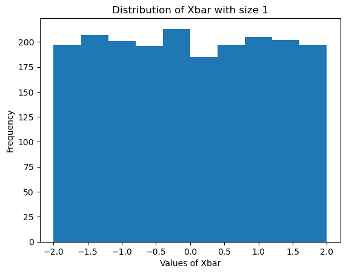

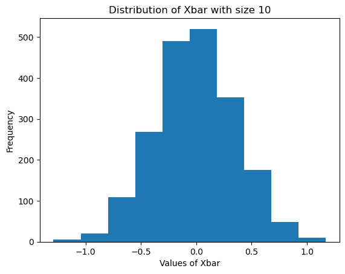

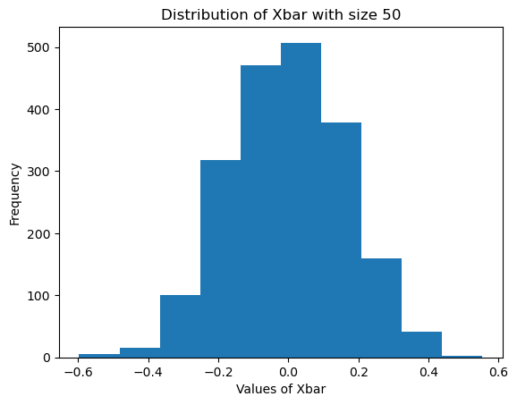

```python
# One way is to write this with repeated code chunks
# We just repeat the code that we had above, with different sample sizes
# Each time will start the process of generating new data from scratch.

num_simulations = 2000

# Simulate with sample size one
sample_size = 1
vec_xbar = [None] * num_simulations

for iteration in range(num_simulations):
    vec_unif  = np.random.uniform(low = -2, high=2, size = sample_size)
    vec_xbar[iteration] = vec_unif.mean()
plt.hist(vec_xbar)
plt.title("Distribution of Xbar with size 1")
plt.ylabel("Frequency")
plt.xlabel("Values of Xbar")
plt.show()

# Simulate with sample size 10
sample_size = 10
vec_xbar = [None] * num_simulations
for iteration in range(num_simulations):
    vec_unif  = np.random.uniform(low = -2, high=2, size = sample_size)
    vec_xbar[iteration] = vec_unif.mean()
plt.hist(vec_xbar)
plt.title("Distribution of Xbar with size 10")
plt.ylabel("Frequency")
plt.xlabel("Values of Xbar")
plt.show()

# Simulate with sample size 50
sample_size = 50
vec_xbar = [None] * num_simulations
for iteration in range(num_simulations):
    vec_unif  = np.random.uniform(low = -2, high=2, size = sample_size)
    vec_xbar[iteration] = vec_unif.mean()
plt.hist(vec_xbar)
plt.title("Distribution of Xbar with size 50")
plt.ylabel("Frequency")
plt.xlabel("Values of Xbar")
plt.show()
```

We can use nested loops to simply our code.

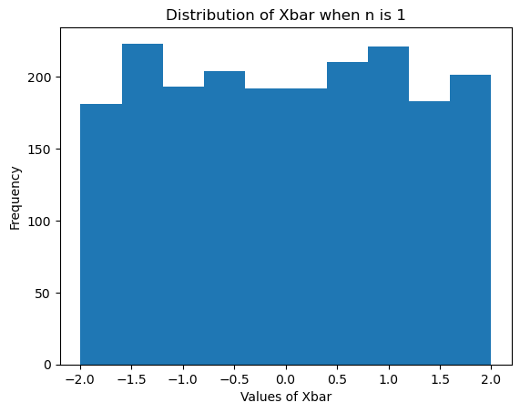

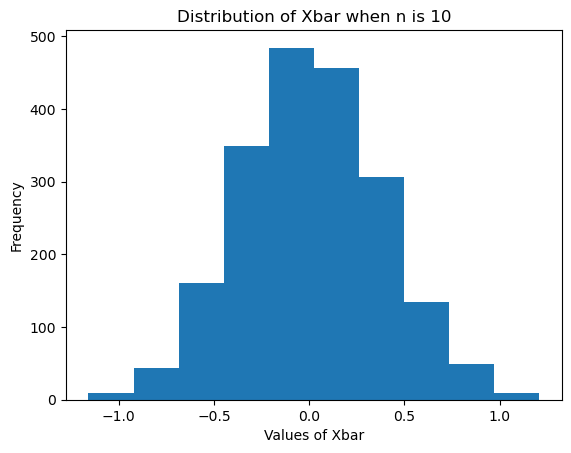

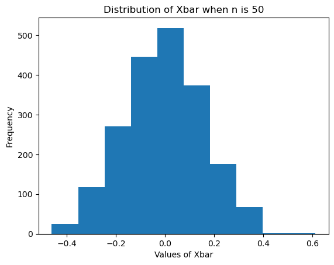

```python
# To evaluate different sample size which just have to write a for-loop within
# another for-loop
num_simulations = 2000
sample_size_list = [1, 10, 50]

for sample_size in sample_size_list:
    # The following command a vector null values, of length "num_simulations"
    vec_xbar = [None] * num_simulations

    for iteration in range(num_simulations):
            vec_unif  = np.random.uniform(low = -2, high=2, size = sample_size)
            vec_xbar[iteration] = vec_unif.mean()
    plt.hist(vec_xbar)
    plt.title("Distribution of Xbar when n is " + str(sample_size))
    plt.ylabel("Frequency")
    plt.xlabel("Values of Xbar")
    plt.show()
```

***Exercise***

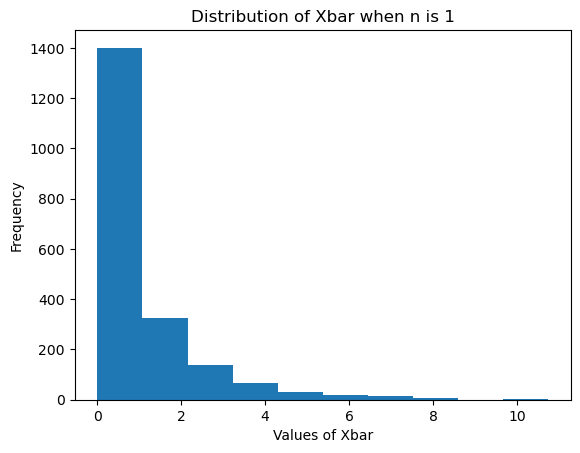

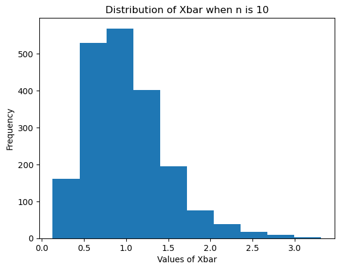

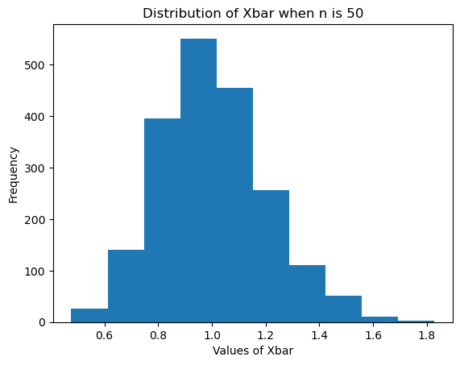

```python
num_simulations = 2000
sample_size_list = [1, 10, 50]

for sample_size in sample_size_list:
    # The following command a vector null values, of length "num_simulations"
    vec_xbar = [None] * num_simulations

    for iteration in range(num_simulations):
            vec_chisqr  = np.random.chisquare(df = 1, size = sample_size)
            vec_xbar[iteration] = vec_chisqr.mean()
    plt.hist(vec_xbar)
    plt.title("Distribution of Xbar when n is " + str(sample_size))
    plt.ylabel("Frequency")
    plt.xlabel("Values of Xbar")
    plt.show()
```

***Exercise***

- Write code that puts all the figures in the same row

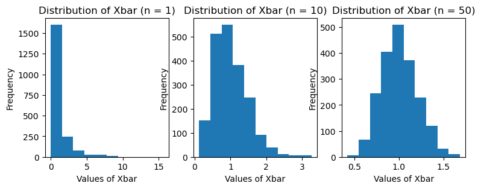

```python
num_simulations = 2000
sample_size_list = [1, 10, 50]
list_index = [0, 1, 2]

fig, list_subfig = plt.subplots(1, 3, figsize = (9, 3))
index = 0

for sample_size in sample_size_list:
    # The following command a vector null values, of length "num_simulations"
    vec_xbar_chisqr = [None] * num_simulations
    for iteration in range(num_simulations):
            vec_chisqr  = np.random.chisquare(df = 1, size = sample_size)
            vec_xbar_chisqr[iteration] = vec_chisqr.mean()
    list_subfig[index].hist(vec_xbar_chisqr)
    list_subfig[index].set_title(f"Distribution of Xbar (n = {str(sample_size)})")
    list_subfig[index].set_ylabel("Frequency")
    list_subfig[index].set_xlabel("Values of Xbar")
    index += 1
```

#### The 95% Confidence Level

Let ''sample_std'' be the sample standard deviation of $X_i$.

```python
# Parameters of a normal random variable
n                 = 10000
population_mean   = 2
population_stdv   = 5

# Create random variable and produce summary statistics
X           = np.random.normal(loc = 2,scale = 5,size = n)
Xbar        = X.mean()
sample_stdv = X.std()

# Check that the sample and standard deviation are close to their
# population values
print(Xbar)
print(sample_stdv)
```

```
2.0480684945806265
4.988722335956281
```

A 95% normal confidence interval is defined by $\ldots$

- lower_bound = $\overline{X} -1.96 \times \displaystyle\frac{\text{sample_stdv}}{\sqrt{n}}$.
- upper_bound = $\overline{X} + 1.96 \times \displaystyle\frac{\text{sample_stdv}}{\sqrt{n}}$.

```python
# Compute new variables for the upper and lower bound

lower_bound = Xbar - 1.96*(sample_stdv / np.sqrt(n))
upper_bound = Xbar + 1.96*(sample_stdv / np.sqrt(n))
```

The following code testifies the following conditions:

lower_bound $\quad \le \quad $ population_mean $\quad \le \quad$ upper_bound

```python
if population_mean >= lower_bound and population_mean <= upper_bound:
    print("The population mean is in the 95% normal confidence interval!")
else:
    print("The population mean is not in the 95\% confidence intervla :(")
```

```
The population mean is in the 95% normal confidence interval!
```

***Exercise***: Test Whether This is a 95% Confidence Interval

Procedure:

- Create a variable called "num_simulations" with value 1000
- Create the simulation parameters "n", "population_mean", "populations_stdv".
- Create an empty vector called "list_test_confidenceinterval".
- Create a loop. At each iteration:
  - Create a vector of normal random variables of size "n".
  - Create a variable "test_confidenceinterval", which tests:

    lower_bound $\quad \le \quad $ population_mean $\quad \le \quad$ upper_bound
  - Append "test_confidenceinterval" to the above list
- Compute the mean of "list_test_confidenceinterval"

Note: The final result should be close to 95%.

```python
num_simulations = 1000
n = 100
population_mean = 2
populations_stdv = 5
list_test_confidenceinterval = []

for interation in range(num_simulations):
    vec_normal = np.random.normal(population_mean, population_stdv, n)
    Xbar = vec_normal.mean()
    sample_stdv = vec_normal.std()
    lower_bound = Xbar - 1.96*(sample_stdv / np.sqrt(n))
    upper_bound = Xbar + 1.96*(sample_stdv / np.sqrt(n))
    if population_mean >= lower_bound and population_mean <= upper_bound:
        test_confidenceinterval = True
    else:
        test_confidenceinterval = False
    list_test_confidenceinterval.append((test_confidenceinterval))

np.mean(list_test_confidenceinterval)
```

[output not shown]

### Linear Regression

Create an empty dataset

```python
dataset = pd.DataFrame([])
```

Create two random variables of size ($n = 50$)

```python
n = 50
dataset["x"] = np.random.normal(loc = 0,scale = 1, size = n)
dataset["e"] = np.random.normal(loc = 0,scale = 1, size = n)
```

Create data from the linear model

$ y = b_0 + b_1 x + e, \qquad b_0 = 1, b_1 = 2.$

```python
# The number b0 is known as the "intercept"
# The number b1 is known as the "slope"
b0 = 1
b1 = 2

# We can compute formulas directly over dataset columns
dataset["y"] = b0 + b1 * dataset["x"] + dataset["e"]
```

Compute the theoretically best fit line

$ p = b_0 + b_1 x$

```python
dataset["p"] = b0 + b1 * dataset["x"]
```

Plot the data

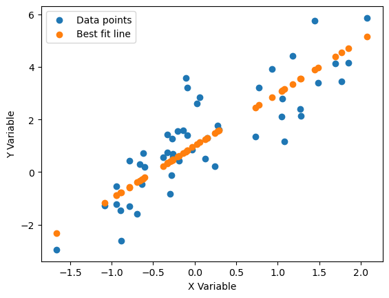

```python
plt.scatter(x = dataset["x"], y = dataset["y"])
plt.scatter(x = dataset["x"], y = dataset["p"])

plt.xlabel("X Variable")
plt.ylabel("Y Variable")
plt.legend(labels = ["Data points", "Best fit line"])
plt.show()
```

***Example***

- Create a new dataset called $\quad$ `subset_above2`
- This subsets records with $y \ge 2$ using $\quad$ `.query()`
- Count the original rows $\quad$ `len(dataset)`
- Count the subsetted rows $\quad$ `len(subset_above2)`
- Compute the proportion of subsetted observations

```python
subset_above2 = dataset.query("y >= 2")
print(len(dataset))
print(len(subset_above2))

print(f"{len(subset_above2) / len(dataset) * 100} %")
```

```
50
17
34.0 %
```

***Example***

- Store the sample mean of $y$ as $\quad$ `ybar`
- Compute the standard deviation of $y$ $\quad$ `stdv_sample`
- Use `.query()` to subset observations that satisfy

$ \qquad abs\left(y - ybar \right) \le stdv\_sample $

$\quad$ HINT: Use `.mean()`,$\text{ }$ `.std()`  
$\quad$ HINT: Use the globals $\ $ `@xbar`,$\text{ }$ `@stdv_sample`

```python
# Note: abs(...) is the absolute value function
# Write your own code

ybar = dataset["y"].mean()
stdv_sample = dataset["y"].std()

subset = dataset.query("abs(y - @ybar) <= @stdv_sample")
```

We have data on $(y,x)$ but we don't know $(b_0,b_1)$

Let's fit an OLS model

- It's a statistical approach to get $(b_0,b_1)$
- No need to know how it works but why we want it

```python
#------------------------------------------------------------------------------#
# We use the subfunction "ols()" in the library "smf"
#---- (i) The first argument is a string called "formula" with the format
#-------- "outcome ~ indepdent_vars"
#----(ii) the second argument is the dataset
# The second line fits the model with standard errors "cov". In this case we
# use "robust" standard errors (HC1)
#-------------------------------------------------------------------------------#

model   = smf.ols(formula = 'y ~  x',data = dataset)
results = model.fit(cov = "HC1")

# Can also run as one line
# results = smf.ols(formula = 'y ~ x',data = dataset).fit(cov = "HC1")

print(results.summary())
```

```
                            OLS Regression Results
==============================================================================
Dep. Variable:                      y   R-squared:                       0.723
Model:                            OLS   Adj. R-squared:                  0.718
Method:                 Least Squares   F-statistic:                     125.5
Date:                Sun, 26 Feb 2023   Prob (F-statistic):           5.40e-15
Time:                        16:40:41   Log-Likelihood:                -72.754
No. Observations:                  50   AIC:                             149.5
Df Residuals:                      48   BIC:                             153.3
Df Model:                           1
Covariance Type:            nonrobust
==============================================================================
                 coef    std err          t      P>|t|      [0.025      0.975]
------------------------------------------------------------------------------
Intercept      1.0856      0.151      7.179      0.000       0.782       1.390
x              1.8988      0.169     11.203      0.000       1.558       2.240
==============================================================================
Omnibus:                        1.364   Durbin-Watson:                   1.868
Prob(Omnibus):                  0.506   Jarque-Bera (JB):                1.148
Skew:                           0.365   Prob(JB):                        0.563
Kurtosis:                       2.870   Cond. No.                         1.20
==============================================================================

Notes:
[1] Standard Errors assume that the covariance matrix of the errors is correctly specified.
```

Compute the estimated best fit line

```python
# We will use ".params" to get the attribute "parameters from the results"

b_list = results.params
print(b_list)

# We can then compute the "estimated" best fit lines
# by extracting the intercept and slop from "b_list"

dataset["p_estimated"] = b_list[0] + b_list[1]  * dataset["x"]

# Note: The estimators for "b0" and "b1" are close to
# the values we used to generate the data
```

```
Intercept    1.085574
x            1.898793
dtype: float64
```

Plot the best fit line

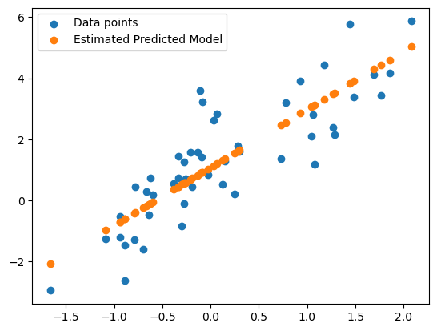

```python
# Use scatter twice, with different "y" inputs
# THe "legend" command creates a box on with the color labels

plt.scatter(x = dataset["x"],y = dataset["y"])
plt.scatter(x = dataset["x"],y = dataset["p_estimated"])

plt.legend(labels = ["Data points","Estimated Predicted Model"])
plt.show()
```

***Example***

- How good is the estimated fit?
- Create two overlapping scatterplots
- $(p \text{ }$ vs $\text{ } x)$ and $(p_{estimated} \text{ }$ vs $\text{ } x)$
- Create a legend to label each plot

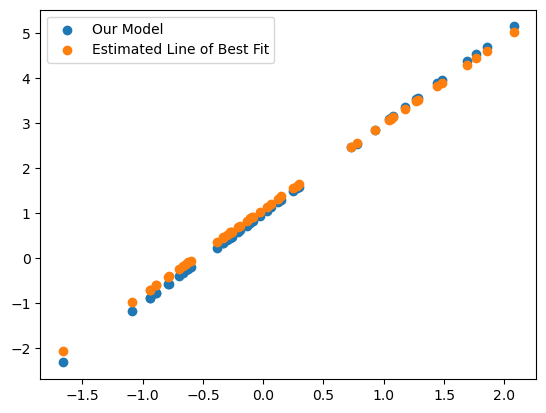

```python
plt.scatter(x = dataset["x"], y = dataset["p"])
plt.scatter(x = dataset["x"], y = dataset["p_estimated"])

plt.legend(labels = ["Our Model", "Estimated Line of Best Fit"])
plt.show()
```

***Example***

- Compute a column with the formula

$\quad$ `sample_error = y - p_estimated`

- Create a lambda function

$\quad$ `fn_positive_error error: error >= 0`

- Compute a column for whether the error is positive

using `.apply()`

```python
dataset["sample_error"] = dataset["y"] - dataset["p_estimated"]

fn_positive_error = lambda error: error >= 0

dataset["sample_error_positive_check"] = dataset["sample_error"].apply(fn_positive_error)
```

***Example***

- Compute a new column

`error_sqr = sample_error ** 2`

- Calculate the mean of `error_sqr`

```python
dataset["error_sqr"] = dataset["sample_error"] ** 2

dataset["error_sqr"].mean()
```

```
1.0749508086915205
```

#### (Optional) Regression Output

Create an empty dataset

```python
dataset = pd.DataFrame([])
```

Create three random variables of size ($n = 100$)

```python
n = 100
dataset["x"] = np.random.normal(loc = 0,scale = 1, size = n)
dataset["z"] = np.random.normal(loc = 0,scale = 1, size = n)
dataset["e"] = np.random.normal(loc = 0,scale = 1, size = n)
```

Create discrete random variable ($n = 100$)

```python
dataset["d"] = np.random.choice(a = [1,2,3],
                                size = n,
                                p = [0.2,0.2,0.6])
```

Create data from the linear model

```python
# We can compute formulas directly over dataset columns
dataset["y"] = 2 + 5 * dataset["x"] + dataset["x"] * dataset["e"]
```

Summaries for univariate regression

```python
# Run the model with multiple variables by using "+"
results_univariate = smf.ols(formula = 'y ~ x',data = dataset).fit(cov_type= "HC1")

# The "summary_col" functions produces nice outputs
# We can add notation for significance by setting "stars" to True
print(summary_col(results_univariate,
                  stars = True))
```

```
========================
                   y
------------------------
Intercept      2.1850***
               (0.1171)
x              5.0127***
               (0.1245)
R-squared      0.9675
R-squared Adj. 0.9671
========================
Standard errors in
parentheses.
* p<.1, ** p<.05,
***p<.01
```

```python
print(results_univariate.summary())
```

```
                            OLS Regression Results
==============================================================================
Dep. Variable:                      y   R-squared:                       0.967
Model:                            OLS   Adj. R-squared:                  0.967
Method:                 Least Squares   F-statistic:                     1622.
Date:                Sun, 26 Feb 2023   Prob (F-statistic):           8.86e-63
Time:                        16:44:33   Log-Likelihood:                -156.10
No. Observations:                 100   AIC:                             316.2
Df Residuals:                      98   BIC:                             321.4
Df Model:                           1
Covariance Type:                  HC1
==============================================================================
                 coef    std err          z      P>|z|      [0.025      0.975]
------------------------------------------------------------------------------
Intercept      2.1850      0.117     18.658      0.000       1.956       2.415
x              5.0127      0.124     40.273      0.000       4.769       5.257
==============================================================================
Omnibus:                        8.870   Durbin-Watson:                   1.738
Prob(Omnibus):                  0.012   Jarque-Bera (JB):                9.509
Skew:                           0.543   Prob(JB):                      0.00861
Kurtosis:                       4.050   Cond. No.                         1.27
==============================================================================

Notes:
[1] Standard Errors are heteroscedasticity robust (HC1)
```

Summaries for multivariate regression

```python
# Run the model with multiple variables by using "+"
results_multivariate = smf.ols(formula = 'y ~ x + z',
                               data = dataset).fit(cov_type = "HC1")
print(summary_col(results_multivariate,
                  stars = True))
```

```
========================
                   y
------------------------
Intercept      2.1733***
               (0.1157)
x              5.0098***
               (0.1236)
z              -0.1158
               (0.1143)
R-squared      0.9678
R-squared Adj. 0.9671
========================
Standard errors in
parentheses.
* p<.1, ** p<.05,
***p<.01
```

Summaries for multivariate regression + categories

```python
# Run the model with multiple variables by using "+"
# This creates a set of distinct indicator variables for each category
results_multivariate_category = smf.ols(formula = 'y ~ x + C(d)',
                                        data = dataset).fit(cov_type = "HC1")

# The results are reported with a base category, T.1
print(summary_col(results_multivariate_category,
                  stars = True))
```

```
========================
                   y
------------------------
Intercept      1.9636***
               (0.2620)
C(d)[T.2]      0.0705
               (0.4091)
C(d)[T.3]      0.2954
               (0.2976)
x              5.0094***
               (0.1245)
R-squared      0.9678
R-squared Adj. 0.9668
========================
Standard errors in
parentheses.
* p<.1, ** p<.05,
***p<.01
```

Summaries for multivariate regression + interaction

```python
# Run the model with multiple variables by using "+"
# This creates a set of distinct indicator variables for each category
results_multivariate_interaction = smf.ols(formula = 'y ~ x + z + z:x',
                                        data = dataset).fit(cov_type = "HC1")

# The results are reported with a base category, T.1
print(summary_col(results_multivariate_interaction,
                  stars = True))
```

```
========================
                   y
------------------------
Intercept      2.1704***
               (0.1166)
x              4.9888***
               (0.1260)
z              -0.1035
               (0.1210)
z:x            -0.1246
               (0.1425)
R-squared      0.9682
R-squared Adj. 0.9672
========================
Standard errors in
parentheses.
* p<.1, ** p<.05,
***p<.01
```

Summaries for multiple columns

```python
list_results = [results_univariate,
                results_multivariate,
                results_multivariate_category,
                results_multivariate_interaction]

print(summary_col(list_results,
                  stars = True))
```

```
======================================================
                  y I       y II     y III     y IIII
------------------------------------------------------
C(d)[T.2]                          0.0705
                                   (0.4091)
C(d)[T.3]                          0.2954
                                   (0.2976)
Intercept      2.1850*** 2.1733*** 1.9636*** 2.1704***
               (0.1171)  (0.1157)  (0.2620)  (0.1166)
R-squared      0.9675    0.9678    0.9678    0.9682
R-squared Adj. 0.9671    0.9671    0.9668    0.9672
x              5.0127*** 5.0098*** 5.0094*** 4.9888***
               (0.1245)  (0.1236)  (0.1245)  (0.1260)
z                        -0.1158             -0.1035
                         (0.1143)            (0.1210)
z:x                                          -0.1246
                                             (0.1425)
======================================================
Standard errors in parentheses.
* p<.1, ** p<.05, ***p<.01
```

Summaries for multiple columns (sorted + titled + stats)

```python
# This list inputs the headings of the table
list_headings   = ["Univariate",
                   "Multivariate",
                   "Categorical",
                   "Interaction"]

# This is the list of regressor names (if you want a particular order)
list_regressors = ["x",
                   "z",
                   "z:x",
                   "C(d)[T.2]",
                   "C(d)[T.3]"]

# This is a function that extracts the sample size
# Can use with other summary statistics
# "nobs" is the number of observations
compute_summary = {'N':lambda model: format(int(model.nobs))}

print(summary_col(list_results,
                  stars = True,
                  model_names = list_headings,
                  info_dict={'N':lambda x: format(int(x.nobs))},
                  regressor_order = ["x","z","z:x","C(d)[T.2]","C(d)[T.3]"]))
```

```
==============================================================
               Univariate Multivariate Categorical Interaction
--------------------------------------------------------------
x              5.0127***  5.0098***    5.0094***   4.9888***
               (0.1245)   (0.1236)     (0.1245)    (0.1260)
z                         -0.1158                  -0.1035
                          (0.1143)                 (0.1210)
z:x                                                -0.1246
                                                   (0.1425)
C(d)[T.2]                              0.0705
                                       (0.4091)
C(d)[T.3]                              0.2954
                                       (0.2976)
Intercept      2.1850***  2.1733***    1.9636***   2.1704***
               (0.1171)   (0.1157)     (0.2620)    (0.1166)
R-squared      0.9675     0.9678       0.9678      0.9682
R-squared Adj. 0.9671     0.9671       0.9668      0.9672
N              100        100          100         100
==============================================================
Standard errors in parentheses.
* p<.1, ** p<.05, ***p<.01
```

Detailed table

```python
print(results_univariate.summary())
```

```
                            OLS Regression Results
==============================================================================
Dep. Variable:                      y   R-squared:                       0.967
Model:                            OLS   Adj. R-squared:                  0.967
Method:                 Least Squares   F-statistic:                     1622.
Date:                Sun, 26 Feb 2023   Prob (F-statistic):           8.86e-63
Time:                        16:46:10   Log-Likelihood:                -156.10
No. Observations:                 100   AIC:                             316.2
Df Residuals:                      98   BIC:                             321.4
Df Model:                           1
Covariance Type:                  HC1
==============================================================================
                 coef    std err          z      P>|z|      [0.025      0.975]
------------------------------------------------------------------------------
Intercept      2.1850      0.117     18.658      0.000       1.956       2.415
x              5.0127      0.124     40.273      0.000       4.769       5.257
==============================================================================
Omnibus:                        8.870   Durbin-Watson:                   1.738
Prob(Omnibus):                  0.012   Jarque-Bera (JB):                9.509
Skew:                           0.543   Prob(JB):                      0.00861
Kurtosis:                       4.050   Cond. No.                         1.27
==============================================================================

Notes:
[1] Standard Errors are heteroscedasticity robust (HC1)
```